# R Notebook

**Descriptive Statistics** Load epiDisplay package for the tab1 function. *Gender*

```r
tab1(BIL$Gender, graph = FALSE)
```

```
BIL$Gender :
        Frequency Percent Cum. percent
1             305    53.9         53.9
2             261    46.1        100.0
  Total       566   100.0        100.0
```

```r
tab1(BIL$GenderCategorical, graph = FALSE)
```

```
BIL$GenderCategorical :
        Frequency Percent Cum. percent
Female        305    53.9         53.9
Male          261    46.1        100.0
  Total       566   100.0        100.0
```

```r
tab1(BIL$EducationCategorical, graph = FALSE)
```

```
BIL$EducationCategorical :
               Frequency   %(NA+)   %(NA-)
Bachelors            192     33.9     34.0
Doctorate             26      4.6      4.6
HighSchool            96     17.0     17.0
LessHighSchool         6      1.1      1.1
Masters               97     17.1     17.2
SomeCollege          147     26.0     26.1
<NA>                   2      0.4      0.0
  Total              566    100.0    100.0
```

*Race*

```r
tab1(BIL$Race, graph = FALSE)
```

```
BIL$Race :
        Frequency Percent Cum. percent
1             383    67.7         67.7
2             113    20.0         87.6
4              55     9.7         97.3
5               2     0.4         97.7
6               4     0.7         98.4
7               9     1.6        100.0
  Total       566   100.0        100.0
```

```r
tab1(BIL$RaceCategorical, graph = FALSE)
```

```
BIL$RaceCategorical :
                              Frequency Percent Cum. percent
Asian                                55     9.7          9.7
BlackorAfricanAmerican              113    20.0         29.7
NativeAmericanAlaskan                 2     0.4         30.0
NativeHawaiianPacificIslander         4     0.7         30.7
Other                                 9     1.6         32.3
White                               383    67.7        100.0
  Total                             566   100.0        100.0
```

*Ethnicity*

```r
tab1(BIL$Ethnicity, graph = FALSE)
```

```
BIL$Ethnicity :
        Frequency Percent Cum. percent
2              66    11.7         11.7
3             500    88.3        100.0
  Total       566   100.0        100.0
```

```r
tab1(BIL$EthnicityCategorical, graph = FALSE)
```

```
BIL$EthnicityCategorical :
            Frequency Percent Cum. percent
Hispanic           66    11.7         11.7
nonHispanic       500    88.3        100.0
  Total           566   100.0        100.0
```

*Education Level*

```r
tab1(BIL$Educ, graph = FALSE)
```

```
BIL$Educ :
        Frequency   %(NA+)   %(NA-)
1               6      1.1      1.1
2              96     17.0     17.1
3             147     26.0     26.1
4             192     33.9     34.1
5              97     17.1     17.2
6              25      4.4      4.4
<NA>            3      0.5      0.0
  Total       566    100.0    100.0
```

```r
tab1(BIL$EducationCategorical, graph = FALSE)
```

```
BIL$EducationCategorical :
               Frequency   %(NA+)   %(NA-)
Bachelors            192     33.9     34.0
Doctorate             26      4.6      4.6
HighSchool            96     17.0     17.0
LessHighSchool         6      1.1      1.1
Masters               97     17.1     17.2
SomeCollege          147     26.0     26.1
<NA>                   2      0.4      0.0
  Total              566    100.0    100.0
```

*Marital Status*

```r
tab1(BIL$Marital, graph = FALSE)
```

```
BIL$Marital :
        Frequency   %(NA+)   %(NA-)
1             353     62.4     62.7
2             206     36.4     36.6
8               4      0.7      0.7
<NA>            3      0.5      0.0
  Total       566    100.0    100.0
```

```r
tab1(BIL$MarriedCategorical, graph = FALSE)
```

```
BIL$MarriedCategorical :
           Frequency   %(NA+)   %(NA-)
Married          353     62.4     63.1
NotMarried       206     36.4     36.9
<NA>               7      1.2      0.0
  Total          566    100.0    100.0
```

*Utah Residental Status*

```r
tab1(BIL$Utah, graph = FALSE)
```

```
BIL$Utah :
        Frequency Percent Cum. percent
0             361    63.8         63.8
1             205    36.2        100.0
  Total       566   100.0        100.0
```

```r
mean(BIL$Income_1, na.rm=TRUE)
```

```
[1] 101.7744227
```

```r
sd(BIL$Income_1, na.rm=TRUE)
```

```
[1] 93.70556932
```

Female/Male (Gender) Utah/NotUtah (Utah) White/nonWhite (White)

**Differences Female/Male Intrinsic Rewards (Gender)**

Interesting Job (JobCharacteristics_4)

```r
#mean of whole sample
mean(BIL$JobCharacteristics_4, na.rm=TRUE)
```

```
[1] 3.828318584
```

```r
#standard deviation of whole sample
sd(BIL$JobCharacteristics_4, na.rm=TRUE)
```

```
[1] 1.017878219
```

```r
#differences of means test
t.test(BIL$JobCharacteristics_4~BIL$GenderCategorical, mu = 0, alternative = "two.sided")
```

```
    Welch Two Sample t-test

data:  BIL$JobCharacteristics_4 by BIL$GenderCategorical
t = -1.6623111, df = 562.91732, p-value = 0.0970071
alternative hypothesis: true difference in means between group Female and group Male is not equal to 0
95 percent confidence interval:
 -0.30772924701  0.02561591771
sample estimates:
mean in group Female   mean in group Male
         3.763157895          3.904214559
```

```r
#standard deviation for Male and Female subsets
tapply(BIL$JobCharacteristics_4, BIL$GenderCategorical, sd, na.rm=TRUE)
```

```
      Female         Male
1.0792788333 0.9376840619
```

```r
#differences of variation test
var.test(BIL$JobCharacteristics_4~BIL$GenderCategorical, ratio = 1, alternative = "two.sided")
```

```
    F test to compare two variances

data:  BIL$JobCharacteristics_4 by BIL$GenderCategorical
F = 1.324812, num df = 303, denom df = 260, p-value = 0.01952362
alternative hypothesis: true ratio of variances is not equal to 1
95 percent confidence interval:
 1.046450563 1.673645251
sample estimates:
ratio of variances
       1.324811994
```

Job autonomy (JobCharacteristics_5)

```r
#mean of whole sample
mean(BIL$JobCharacteristics_5, na.rm=TRUE)
```

```
[1] 4.056637168
```

```r
#standard deviation of whole sample
sd(BIL$JobCharacteristics_5, na.rm=TRUE)
```

```
[1] 0.9912629048
```

```r
#differences of means test
t.test(BIL$JobCharacteristics_5~BIL$GenderCategorical, mu = 0, alternative = "two.sided")
```

```
    Welch Two Sample t-test

data:  BIL$JobCharacteristics_5 by BIL$GenderCategorical
t = -0.36120518, df = 560.70903, p-value = 0.7180821
alternative hypothesis: true difference in means between group Female and group Male is not equal to 0
95 percent confidence interval:
 -0.1933549651  0.1332874112
sample estimates:
mean in group Female   mean in group Male
         4.042763158          4.072796935
```

```r
#standard deviation for Male and Female subsets
tapply(BIL$JobCharacteristics_5, BIL$GenderCategorical, sd, na.rm=TRUE)
```

```
     Female        Male
1.031587067 0.943840066
```

```r
#differences of variation test
var.test(BIL$JobCharacteristics_5~BIL$GenderCategorical, ratio = 1, alternative = "two.sided")
```

```
    F test to compare two variances

data:  BIL$JobCharacteristics_5 by BIL$GenderCategorical
F = 1.1945792, num df = 303, denom df = 260, p-value = 0.1392822
alternative hypothesis: true ratio of variances is not equal to 1
95 percent confidence interval:
 0.9435815154 1.5091211924
sample estimates:
ratio of variances
        1.19457923
```

Help Others (JobCharacteristics_6)

```r
#mean of whole sample
mean(BIL$JobCharacteristics_6, na.rm=TRUE)
```

```
[1] 4.148672566
```

```r
#standard deviation of whole sample
sd(BIL$JobCharacteristics_6, na.rm=TRUE)
```

```
[1] 0.8624469399
```

```r
#differences of means test
t.test(BIL$JobCharacteristics_6~BIL$GenderCategorical, mu = 0, alternative = "two.sided")
```

```
    Welch Two Sample t-test

data:  BIL$JobCharacteristics_6 by BIL$GenderCategorical
t = 0.9625554, df = 556.69486, p-value = 0.3361886
alternative hypothesis: true difference in means between group Female and group Male is not equal to 0
95 percent confidence interval:
 -0.07264740934  0.21226729239
sample estimates:
mean in group Female   mean in group Male
         4.180921053          4.111111111
```

```r
#standard deviation for Male and Female subsets
tapply(BIL$JobCharacteristics_6, BIL$GenderCategorical, sd, na.rm=TRUE)
```

```
      Female         Male
0.8807612633 0.8407363480
```

```r
#differences of variation test
var.test(BIL$JobCharacteristics_6~BIL$GenderCategorical, ratio = 1, alternative = "two.sided")
```

```
    F test to compare two variances

data:  BIL$JobCharacteristics_6 by BIL$GenderCategorical
F = 1.0974804, num df = 303, denom df = 260, p-value = 0.4393785
alternative hypothesis: true ratio of variances is not equal to 1
95 percent confidence interval:
 0.8668844818 1.3864554588
sample estimates:
ratio of variances
       1.097480377
```

Job useful to society (JobCharacteristics_7)

```r
#mean of whole sample
mean(BIL$JobCharacteristics_7, na.rm=TRUE)
```

```
[1] 4.008849558
```

```r
#standard deviation of whole sample
sd(BIL$JobCharacteristics_7, na.rm=TRUE)
```

```
[1] 0.9829718222
```

```r
#differences of means test
t.test(BIL$JobCharacteristics_7~BIL$GenderCategorical, mu = 0, alternative = "two.sided")
```

```
    Welch Two Sample t-test

data:  BIL$JobCharacteristics_7 by BIL$GenderCategorical
t = 1.2260845, df = 544.566, p-value = 0.2206968
alternative hypothesis: true difference in means between group Female and group Male is not equal to 0
95 percent confidence interval:
 -0.06135447573  0.26515060398
sample estimates:
mean in group Female   mean in group Male
         4.055921053          3.954022989
```

```r
#standard deviation for Male and Female subsets
tapply(BIL$JobCharacteristics_7, BIL$GenderCategorical, sd, na.rm=TRUE)
```

```
      Female         Male
0.9682234115 0.9989384286
```

```r
#differences of variation test
var.test(BIL$JobCharacteristics_7~BIL$GenderCategorical, ratio = 1, alternative = "two.sided")
```

```
    F test to compare two variances

data:  BIL$JobCharacteristics_7 by BIL$GenderCategorical
F = 0.9394501, num df = 303, denom df = 260, p-value = 0.5993029
alternative hypothesis: true ratio of variances is not equal to 1
95 percent confidence interval:
 0.7420585668 1.1868145899
sample estimates:
ratio of variances
      0.9394501027
```

Job satisfaction (JobSat)

```r
#mean of whole sample
mean(BIL$JobSat, na.rm=TRUE)
```

```
[1] 7.44765282
```

```r
#standard deviation of whole sample
sd(BIL$JobSat, na.rm=TRUE)
```

```
[1] 2.313424047
```

```r
#differences of means test
t.test(BIL$JobSat~BIL$GenderCategorical, mu = 0, alternative = "two.sided")
```

```
    Welch Two Sample t-test

data:  BIL$JobSat by BIL$GenderCategorical
t = -2.4132826, df = 561.7524, p-value = 0.01612859
alternative hypothesis: true difference in means between group Female and group Male is not equal to 0
95 percent confidence interval:
 -0.84358249853 -0.08654335478
sample estimates:
mean in group Female   mean in group Male
         7.232437529          7.697500456
```

```r
#standard deviation for Male and Female subsets
tapply(BIL$JobSat, BIL$GenderCategorical, sd, na.rm=TRUE)
```

```
     Female        Male
2.434940916 2.141415003
```

```r
#differences of variation test
var.test(BIL$JobSat~BIL$GenderCategorical, ratio = 1, alternative = "two.sided")
```

```
    F test to compare two variances

data:  BIL$JobSat by BIL$GenderCategorical
F = 1.2929305, num df = 302, denom df = 260, p-value = 0.03295216
alternative hypothesis: true ratio of variances is not equal to 1
95 percent confidence interval:
 1.021105675 1.633698167
sample estimates:
ratio of variances
       1.292930477
```

**Differences / Extrinsic Rewards ()**

Income in $1000’s (Income_1)

```r
#mean of whole sample
mean(BIL$Income_1, na.rm=TRUE)
```

```
[1] 101.7744227
```

```r
#standard deviation of whole sample
sd(BIL$Income_1, na.rm=TRUE)
```

```
[1] 93.70556932
```

```r
#differences of means test
t.test(BIL$Income_1~BIL$GenderCategorical, mu = 0, alternative = "two.sided")
```

```
    Welch Two Sample t-test

data:  BIL$Income_1 by BIL$GenderCategorical
t = -4.1149568, df = 502.36296, p-value = 0.00004525397
alternative hypothesis: true difference in means between group Female and group Male is not equal to 0
95 percent confidence interval:
 -48.15187233 -17.03041181
sample estimates:
mean in group Female   mean in group Male
         86.66556291         119.25670498
```

```r
#standard deviation for Male and Female subsets
tapply(BIL$Income_1, BIL$GenderCategorical, sd, na.rm=TRUE)
```

```
      Female         Male
 83.28798101 101.86831244
```

```r
#differences of variation test
var.test(BIL$Income_1~BIL$GenderCategorical, ratio = 1, alternative = "two.sided")
```

```
    F test to compare two variances

data:  BIL$Income_1 by BIL$GenderCategorical
F = 0.66847696, num df = 301, denom df = 260, p-value = 0.0007551083
alternative hypothesis: true ratio of variances is not equal to 1
95 percent confidence interval:
 0.5278525399 0.8448334629
sample estimates:
ratio of variances
      0.6684769635
```

Perception of Income (JobCharacteristics_2)

```r
#mean of whole sample
mean(BIL$JobCharacteristics_2, na.rm=TRUE)
```

```
[1] 3.007079646
```

```r
#standard deviation of whole sample
sd(BIL$JobCharacteristics_2, na.rm=TRUE)
```

```
[1] 1.181995309
```

```r
#differences of means test
t.test(BIL$JobCharacteristics_2~BIL$GenderCategorical, mu = 0, alternative = "two.sided")
```

```
    Welch Two Sample t-test

data:  BIL$JobCharacteristics_2 by BIL$GenderCategorical
t = -3.7817585, df = 557.42718, p-value = 0.0001725461
alternative hypothesis: true difference in means between group Female and group Male is not equal to 0
95 percent confidence interval:
 -0.5642583125 -0.1784821593
sample estimates:
mean in group Female   mean in group Male
         2.835526316          3.206896552
```

```r
#standard deviation for Male and Female subsets
tapply(BIL$JobCharacteristics_2, BIL$GenderCategorical, sd, na.rm=TRUE)
```

```
     Female        Male
1.196496971 1.134812059
```

```r
#differences of variation test
var.test(BIL$JobCharacteristics_2~BIL$GenderCategorical, ratio = 1, alternative = "two.sided")
```

```
    F test to compare two variances

data:  BIL$JobCharacteristics_2 by BIL$GenderCategorical
F = 1.1116686, num df = 303, denom df = 260, p-value = 0.378722
alternative hypothesis: true ratio of variances is not equal to 1
95 percent confidence interval:
 0.8780915306 1.4043795010
sample estimates:
ratio of variances
        1.11166856
```

Job security (JobCharacteristics_1)

```r
#mean of whole sample
mean(BIL$JobCharacteristics_1, na.rm=TRUE)
```

```
[1] 3.994690265
```

```r
#standard deviation of whole sample
sd(BIL$JobCharacteristics_1, na.rm=TRUE)
```

```
[1] 0.9592624889
```

```r
#differences of means test
t.test(BIL$JobCharacteristics_1~BIL$GenderCategorical, mu = 0, alternative = "two.sided")
```

```
    Welch Two Sample t-test

data:  BIL$JobCharacteristics_1 by BIL$GenderCategorical
t = -1.4526214, df = 560.71367, p-value = 0.1468883
alternative hypothesis: true difference in means between group Female and group Male is not equal to 0
95 percent confidence interval:
 -0.27445643003  0.04109284866
sample estimates:
mean in group Female   mean in group Male
         3.940789474          4.057471264
```

```r
#standard deviation for Male and Female subsets
tapply(BIL$JobCharacteristics_1, BIL$GenderCategorical, sd, na.rm=TRUE)
```

```
      Female         Male
0.9965852763 0.9117564010
```

```r
#differences of variation test
var.test(BIL$JobCharacteristics_1~BIL$GenderCategorical, ratio = 1, alternative = "two.sided")
```

```
    F test to compare two variances

data:  BIL$JobCharacteristics_1 by BIL$GenderCategorical
F = 1.1947342, num df = 303, denom df = 260, p-value = 0.1389944
alternative hypothesis: true ratio of variances is not equal to 1
95 percent confidence interval:
 0.9437039138 1.5093169509
sample estimates:
ratio of variances
       1.194734187
```

Promotional opportunities (JobCharacteristics_3)

```r
#mean of whole sample
mean(BIL$JobCharacteristics_3, na.rm=TRUE)
```

```
[1] 3.201769912
```

```r
#standard deviation of whole sample
sd(BIL$JobCharacteristics_3, na.rm=TRUE)
```

```
[1] 1.179763041
```

```r
#differences of means test
t.test(BIL$JobCharacteristics_3~BIL$GenderCategorical, mu = 0, alternative = "two.sided")
```

```
    Welch Two Sample t-test

data:  BIL$JobCharacteristics_3 by BIL$GenderCategorical
t = -2.2595512, df = 557.9797, p-value = 0.02423402
alternative hypothesis: true difference in means between group Female and group Male is not equal to 0
95 percent confidence interval:
 -0.4171430769 -0.0291666630
sample estimates:
mean in group Female   mean in group Male
         3.098684211          3.321839080
```

```r
#standard deviation for Male and Female subsets
tapply(BIL$JobCharacteristics_3, BIL$GenderCategorical, sd, na.rm=TRUE)
```

```
     Female        Male
1.206472470 1.138429278
```

```r
#differences of variation test
var.test(BIL$JobCharacteristics_3~BIL$GenderCategorical, ratio = 1, alternative = "two.sided")
```

```
    F test to compare two variances

data:  BIL$JobCharacteristics_3 by BIL$GenderCategorical
F = 1.1231111, num df = 303, denom df = 260, p-value = 0.3342806
alternative hypothesis: true ratio of variances is not equal to 1
95 percent confidence interval:
 0.8871298351 1.4188349526
sample estimates:
ratio of variances
       1.123111102
```

**Differences / Work Quality ()**

Job engagement (Eng_1)

```r
#mean of whole sample
mean(BIL$Eng_1, na.rm=TRUE)
```

```
[1] 7.927433628
```

```r
#standard deviation of whole sample
sd(BIL$Eng_1, na.rm=TRUE)
```

```
[1] 2.016784525
```

```r
#differences of means test
t.test(BIL$Eng_1~BIL$GenderCategorical, mu = 0, alternative = "two.sided")
```

```
    Welch Two Sample t-test

data:  BIL$Eng_1 by BIL$GenderCategorical
t = -2.9118507, df = 559.17064, p-value = 0.003736307
alternative hypothesis: true difference in means between group Female and group Male is not equal to 0
95 percent confidence interval:
 -0.8101384795 -0.1574457108
sample estimates:
mean in group Female   mean in group Male
         7.703947368          8.187739464
```

```r
#standard deviation for Male and Female subsets
tapply(BIL$Eng_1, BIL$GenderCategorical, sd, na.rm=TRUE)
```

```
     Female        Male
2.205121000 1.740690365
```

```r
#differences of variation test
var.test(BIL$Eng_1~BIL$GenderCategorical, ratio = 1, alternative = "two.sided")
```

```
    F test to compare two variances

data:  BIL$Eng_1 by BIL$GenderCategorical
F = 1.6048033, num df = 303, denom df = 260, p-value = 0.00009286273
alternative hypothesis: true ratio of variances is not equal to 1
95 percent confidence interval:
 1.267611774 2.027360393
sample estimates:
ratio of variances
       1.604803266
```

Meaningful career (MW_PM_1)

```r
#mean of whole sample
mean(BIL$MW_PM_1, na.rm=TRUE)
```

```
[1] 3.946902655
```

```r
#standard deviation of whole sample
sd(BIL$MW_PM_1, na.rm=TRUE)
```

```
[1] 1.136442658
```

```r
#differences of means test
t.test(BIL$MW_PM_1~BIL$GenderCategorical, mu = 0, alternative = "two.sided")
```

```
    Welch Two Sample t-test

data:  BIL$MW_PM_1 by BIL$GenderCategorical
t = -2.0106093, df = 559.33258, p-value = 0.04484619
alternative hypothesis: true difference in means between group Female and group Male is not equal to 0
95 percent confidence interval:
 -0.378098345296 -0.004413249784
sample estimates:
mean in group Female   mean in group Male
         3.858552632          4.049808429
```

```r
#standard deviation for Male and Female subsets
tapply(BIL$MW_PM_1, BIL$GenderCategorical, sd, na.rm=TRUE)
```

```
     Female        Male
1.170198938 1.089023010
```

```r
#differences of variation test
var.test(BIL$MW_PM_1~BIL$GenderCategorical, ratio = 1, alternative = "two.sided")
```

```
    F test to compare two variances

data:  BIL$MW_PM_1 by BIL$GenderCategorical
F = 1.1546365, num df = 303, denom df = 260, p-value = 0.2317469
alternative hypothesis: true ratio of variances is not equal to 1
95 percent confidence interval:
 0.9120313187 1.4586612484
sample estimates:
ratio of variances
       1.154636513
```

Organizational commitment (Comm_1)

```r
#mean of whole sample
mean(BIL$Comm_1, na.rm=TRUE)
```

```
[1] 5.104609929
```

```r
#standard deviation of whole sample
sd(BIL$Comm_1, na.rm=TRUE)
```

```
[1] 1.823873659
```

```r
#differences of means test
t.test(BIL$Comm_1~BIL$GenderCategorical, mu = 0, alternative = "two.sided")
```

```
    Welch Two Sample t-test

data:  BIL$Comm_1 by BIL$GenderCategorical
t = -2.4188501, df = 559.57851, p-value = 0.01588765
alternative hypothesis: true difference in means between group Female and group Male is not equal to 0
95 percent confidence interval:
 -0.66807990314 -0.06929728285
sample estimates:
mean in group Female   mean in group Male
         4.933993399          5.302681992
```

```r
#standard deviation for Male and Female subsets
tapply(BIL$Comm_1, BIL$GenderCategorical, sd, na.rm=TRUE)
```

```
     Female        Male
1.884653839 1.733258517
```

```r
#differences of variation test
var.test(BIL$Comm_1~BIL$GenderCategorical, ratio = 1, alternative = "two.sided")
```

```
    F test to compare two variances

data:  BIL$Comm_1 by BIL$GenderCategorical
F = 1.182324, num df = 302, denom df = 260, p-value = 0.1639574
alternative hypothesis: true ratio of variances is not equal to 1
95 percent confidence interval:
 0.9337530173 1.4939399803
sample estimates:
ratio of variances
       1.182323988
```

Student’s Choice 1 (BirthYear)

```r
#mean of whole sample
mean(BIL$BirthYear, na.rm=TRUE)
```

```
[1] 1977.339858
```

```r
#standard deviation of whole sample
sd(BIL$BirthYear, na.rm=TRUE)
```

```
[1] 13.99389268
```

```r
#differences of means test
t.test(BIL$BirthYear~BIL$GenderCategorical, mu = 0, alternative = "two.sided")
```

```
    Welch Two Sample t-test

data:  BIL$BirthYear by BIL$GenderCategorical
t = 2.994503, df = 553.7445, p-value = 0.002871766
alternative hypothesis: true difference in means between group Female and group Male is not equal to 0
95 percent confidence interval:
 1.207713612 5.812945494
sample estimates:
mean in group Female   mean in group Male
          1978.97010           1975.45977
```

```r
#standard deviation for Male and Female subsets
tapply(BIL$BirthYear, BIL$GenderCategorical, sd, na.rm=TRUE)
```

```
     Female        Male
14.13019591 13.62108484
```

```r
#differences of variation test
var.test(BIL$BirthYear~BIL$GenderCategorical, ratio = 1, alternative = "two.sided")
```

```
    F test to compare two variances

data:  BIL$BirthYear by BIL$GenderCategorical
F = 1.0761504, num df = 300, denom df = 260, p-value = 0.5428865
alternative hypothesis: true ratio of variances is not equal to 1
95 percent confidence interval:
 0.849629123 1.360335941
sample estimates:
ratio of variances
       1.076150397
```

Student’s Choice 2 (YearsOld)

```r
#mean of whole sample
mean(BIL$YearsOld, na.rm=TRUE)
```

```
[1] 47.66014235
```

```r
#standard deviation of whole sample
sd(BIL$YearsOld, na.rm=TRUE)
```

```
[1] 13.99389268
```

```r
#differences of means test
t.test(BIL$YearsOld~BIL$GenderCategorical, mu = 0, alternative = "two.sided")
```

```
    Welch Two Sample t-test

data:  BIL$YearsOld by BIL$GenderCategorical
t = -2.994503, df = 553.7445, p-value = 0.002871766
alternative hypothesis: true difference in means between group Female and group Male is not equal to 0
95 percent confidence interval:
 -5.812945494 -1.207713612
sample estimates:
mean in group Female   mean in group Male
         46.02990033          49.54022989
```

```r
#standard deviation for Male and Female subsets
tapply(BIL$YearsOld, BIL$GenderCategorical, sd, na.rm=TRUE)
```

```
     Female        Male
14.13019591 13.62108484
```

```r
#differences of variation test
var.test(BIL$YearsOld~BIL$GenderCategorical, ratio = 1, alternative = "two.sided")
```

```
    F test to compare two variances

data:  BIL$YearsOld by BIL$GenderCategorical
F = 1.0761504, num df = 300, denom df = 260, p-value = 0.5428865
alternative hypothesis: true ratio of variances is not equal to 1
95 percent confidence interval:
 0.849629123 1.360335941
sample estimates:
ratio of variances
       1.076150397
```

Student’s Choice 3 (EqualityValue)

```r
#mean of whole sample
mean(BIL$EqualityValue, na.rm=TRUE)
```

```
[1] 7.887537994
```

```r
#standard deviation of whole sample
sd(BIL$EqualityValue, na.rm=TRUE)
```

```
[1] 1.767280835
```

```r
#differences of means test
t.test(BIL$EqualityValue~BIL$GenderCategorical, mu = 0, alternative = "two.sided")
```

```
    Welch Two Sample t-test

data:  BIL$EqualityValue by BIL$GenderCategorical
t = -2.2013662, df = 561.12976, p-value = 0.02811646
alternative hypothesis: true difference in means between group Female and group Male is not equal to 0
95 percent confidence interval:
 -0.61107607606 -0.03479146636
sample estimates:
mean in group Female   mean in group Male
         7.738095238          8.061029009
```

```r
#standard deviation for Male and Female subsets
tapply(BIL$EqualityValue, BIL$GenderCategorical, sd, na.rm=TRUE)
```

```
     Female        Male
1.905771768 1.577401656
```

```r
#differences of variation test
var.test(BIL$EqualityValue~BIL$GenderCategorical, ratio = 1, alternative = "two.sided")
```

```
    F test to compare two variances

data:  BIL$EqualityValue by BIL$GenderCategorical
F = 1.4596784, num df = 302, denom df = 260, p-value = 0.001739472
alternative hypothesis: true ratio of variances is not equal to 1
95 percent confidence interval:
 1.152796662 1.844394599
sample estimates:
ratio of variances
       1.459678439
```

Student’s Choice 4 (SafeConditions_2)

```r
#mean of whole sample
mean(BIL$SafeConditions_2, na.rm=TRUE)
```

```
[1] 5.542402827
```

```r
#standard deviation of whole sample
sd(BIL$SafeConditions_2, na.rm=TRUE)
```

```
[1] 1.482930805
```

```r
#differences of means test
t.test(BIL$SafeConditions_2~BIL$GenderCategorical, mu = 0, alternative = "two.sided")
```

```
    Welch Two Sample t-test

data:  BIL$SafeConditions_2 by BIL$GenderCategorical
t = -2.5500208, df = 558.54846, p-value = 0.01103752
alternative hypothesis: true difference in means between group Female and group Male is not equal to 0
95 percent confidence interval:
 -0.5592698389 -0.0725748945
sample estimates:
mean in group Female   mean in group Male
         5.396721311          5.712643678
```

```r
#standard deviation for Male and Female subsets
tapply(BIL$SafeConditions_2, BIL$GenderCategorical, sd, na.rm=TRUE)
```

```
     Female        Male
1.514183731 1.429696412
```

```r
#differences of variation test
var.test(BIL$SafeConditions_2~BIL$GenderCategorical, ratio = 1, alternative = "two.sided")
```

```
    F test to compare two variances

data:  BIL$SafeConditions_2 by BIL$GenderCategorical
F = 1.1216813, num df = 304, denom df = 260, p-value = 0.339295
alternative hypothesis: true ratio of variances is not equal to 1
95 percent confidence interval:
 0.8861403537 1.4167449814
sample estimates:
ratio of variances
       1.121681345
```

**Proportions for Whole Sample**

```r
tab1(BIL$HighIncome, graph = FALSE)
```

```
BIL$HighIncome :
        Frequency   %(NA+)   %(NA-)
0             379     67.0     67.3
1             184     32.5     32.7
<NA>            3      0.5      0.0
  Total       566    100.0    100.0
```

**Married or Cohabitating vs Single (Married)**

Income above $100,000 (HighIncome)

```r
MarriedHighIncome <- table(BIL$MarriedCategorical, BIL$HighIncome)
MarriedHighIncome <- addmargins(MarriedHighIncome)
MarriedHighIncome
```

```
               0   1 Sum
  Married    214 139 353
  NotMarried 164  42 206
  Sum        378 181 559
```

```r
prop.test(x = c(139, 42), n = c(353, 206), correct = F, alternative = "two.sided")
```

```
    2-sample test for equality of proportions without continuity correction

data:  c(139, 42) out of c(353, 206)
X-squared = 21.422052, df = 1, p-value = 0.000003685084
alternative hypothesis: two.sided
95 percent confidence interval:
 0.1148868965 0.2648815240
sample estimates:
      prop 1       prop 2
0.3937677054 0.2038834951
```

```r
sqrt(21.422052)
```

```
[1] 4.628396267
```

College Degree (CollegeDegree)

```r
tab1(BIL$CollegeDegree, graph = FALSE)
```

```
BIL$CollegeDegree :
        Frequency   %(NA+)   %(NA-)
0             249     44.0     44.2
1             314     55.5     55.8
<NA>            3      0.5      0.0
  Total       566    100.0    100.0
```

```r
MarriedCollegeDegree <- table(BIL$MarriedCategorical, BIL$CollegeDegree)
MarriedCollegeDegree <- addmargins(MarriedCollegeDegree)
MarriedCollegeDegree
```

```
               0   1 Sum
  Married    127 226 353
  NotMarried 121  85 206
  Sum        248 311 559
```

```r
prop.test(x = c(226, 85), n = c(353, 206), correct = F, alternative = "two.sided")
```

```
    2-sample test for equality of proportions without continuity correction

data:  c(226, 85) out of c(353, 206)
X-squared = 27.302744, df = 1, p-value = 0.0000001739644
alternative hypothesis: two.sided
95 percent confidence interval:
 0.1437829396 0.3114275997
sample estimates:
      prop 1       prop 2
0.6402266289 0.4126213592
```

```r
sqrt(27.302744)
```

```
[1] 5.225202771
```

In Sales or Business Development (SAL, 1 Yes, 2 No)

```r
tab1(BIL$SAL, graph = FALSE)
```

```
BIL$SAL :
        Frequency   %(NA+)   %(NA-)
1             113     20.0     20.2
2             447     79.0     79.8
<NA>            6      1.1      0.0
  Total       566    100.0    100.0
```

```r
MarriedSAL <- table(BIL$MarriedCategorical, BIL$SAL)
MarriedSAL <- addmargins(MarriedSAL)
MarriedSAL
```

```
               1   2 Sum
  Married     71 279 350
  NotMarried  40 166 206
  Sum        111 445 556
```

```r
prop.test(x = c(71, 40), n = c(350, 206), correct = F, alternative = "two.sided")
```

```
    2-sample test for equality of proportions without continuity correction

data:  c(71, 40) out of c(350, 206)
X-squared = 0.061179399, df = 1, p-value = 0.8046415
alternative hypothesis: two.sided
95 percent confidence interval:
 -0.05982067087  0.07718544202
sample estimates:
      prop 1       prop 2
0.2028571429 0.1941747573
```

```r
sqrt(.0435)
```

```
[1] 0.2085665361
```

More than 10 years in organization (OrgYearsMoreThanTen)

```r
tab1(BIL$OrgYearsMoreThanTen, graph = FALSE)
```

```
BIL$OrgYearsMoreThanTen :
        Frequency   %(NA+)   %(NA-)
0             399     70.5     71.4
1             160     28.3     28.6
<NA>            7      1.2      0.0
  Total       566    100.0    100.0
```

```r
MarriedOrgYears_table <- table(BIL$MarriedCategorical, BIL$OrgYearsMoreThanTen)


MarriedOrgYears_table <- addmargins(MarriedOrgYears_table)


MarriedOrgYears_table
```

```
               0   1 Sum
  Married    238 111 349
  NotMarried 157  49 206
  Sum        395 160 555
```

```r
prop.test(x = c(111, 49), n = c(349, 206), correct = F)
```

```
    2-sample test for equality of proportions without continuity correction

data:  c(111, 49) out of c(349, 206)
X-squared = 4.0595873, df = 1, p-value = 0.04392123
alternative hypothesis: two.sided
95 percent confidence interval:
 0.004240522882 0.156134473640
sample estimates:
      prop 1       prop 2
0.3180515759 0.2378640777
```

```r
sqrt(4.4969)
```

```
[1] 2.120589541
```

Student Choice (SafeConditions_2)

```r
tab1(BIL$SafeConditions_2, graph = FALSE)
```

```
BIL$SafeConditions_2 :
        Frequency Percent Cum. percent
1              15     2.7          2.7
2              20     3.5          6.2
3              28     4.9         11.1
4              43     7.6         18.7
5              88    15.5         34.3
6             218    38.5         72.8
7             154    27.2        100.0
  Total       566   100.0        100.0
```

```r
MarriedSafeConditions_2 <- table(BIL$MarriedCategorical, BIL$SafeConditions_2)


MarriedSafeConditions_2 <- addmargins(MarriedSafeConditions_2)


MarriedSafeConditions_2
```

```
               1   2   3   4   5   6   7 Sum
  Married     10  13  21  21  44 143 101 353
  NotMarried   5   7   7  21  41  73  52 206
  Sum         15  20  28  42  85 216 153 559
```

```r
prop.test(x = c(244, 125), n = c(353, 206), correct = F)
```

```
    2-sample test for equality of proportions without continuity correction

data:  c(244, 125) out of c(353, 206)
X-squared = 4.1322366, df = 1, p-value = 0.04207371
alternative hypothesis: two.sided
95 percent confidence interval:
 0.002130138065 0.166713889548
sample estimates:
      prop 1       prop 2
0.6912181303 0.6067961165
```

```r
sqrt(4.1322366)
```

```
[1] 2.032790348
```

**Subsetting Female Respondents**

```r
#Create a subset of only female respondents
Female <- subset(BIL, Gender == 1)
```

**Proportions Female in Utah and Female not in Utah**

```r
#Income above $100,000
FemaleUtahHighIncome <- table(Female$Utah, Female$HighIncome)
FemaleUtahHighIncome <- addmargins(FemaleUtahHighIncome)
FemaleUtahHighIncome
```

```
        0   1 Sum
  0   136  55 191
  1    91  20 111
  Sum 227  75 302
```

```r
prop.test(x = c(20, 55), n = c(111, 191), correct = F, alternative = "two.sided")
```

```
    2-sample test for equality of proportions without continuity correction

data:  c(20, 55) out of c(111, 191)
X-squared = 4.3685357, df = 1, p-value = 0.03660844
alternative hypothesis: two.sided
95 percent confidence interval:
 -0.20388148579 -0.01167438421
sample estimates:
      prop 1       prop 2
0.1801801802 0.2879581152
```

```r
sqrt(4.3685357)
```

```
[1] 2.090104232
```

**MGMT 3345 Unit 2 Project**

**STEP 1: TESTS OF INDEPENDENCE**

**Q1** Is there a relationship between gender (GenderCategorical) and the opportunity to learn and grow in a job (Engagement_Q12_12)?

```r
Step1Q1 <- table(BIL$GenderCategorical, BIL$Engagement_Q12_12)
Step1Q1
```

```
           1   2   3   4   5
  Female  28  28  36 105 107
  Male     8  20  39  86 108
```

```r
chisq.test(Step1Q1 [, 1 : 5], correct = F)
```

```
    Pearson's Chi-squared test

data:  Step1Q1[, 1:5]
X-squared = 11.251753, df = 4, p-value = 0.0238757
```

There is a relationship between Gender and Engagment.

**Q2** Is there a relationship between gender (GenderCategorical) and their position or leadership role in the organization (Position)?

```r
Step1Q2 <- table(BIL$GenderCategorical, BIL$Position)
Step1Q2
```

```
           1   2   3   4   5   6
  Female 137  45  71  21  16  12
  Male    79  47  66  33  21  15
```

```r
chisq.test(Step1Q2 [, 1 : 6], correct = F)
```

```
    Pearson's Chi-squared test

data:  Step1Q2[, 1:6]
X-squared = 16.577838, df = 5, p-value = 0.005374099
```

There is a relationship between Gender and Position

**Q3** Student’s Choice (how would you describe relations at your workplace… - … between management and employees?. WorkRelations_1)

```r
Step1Q3 <- table(BIL$RaceCategorical, BIL$WorkRelations_1)
Step1Q3
```

```
                                  1   2   3   4   5
  Asian                           0   2  20  19  14
  BlackorAfricanAmerican          4   7  26  51  24
  NativeAmericanAlaskan           0   0   0   2   0
  NativeHawaiianPacificIslander   0   1   1   2   0
  Other                           0   0   2   5   2
  White                          14  29  87 165  88
```

```r
chisq.test(Step1Q3 [, 1 : 5], correct = F)
```

```
    Pearson's Chi-squared test

data:  Step1Q3[, 1:5]
X-squared = 15.240989, df = 20, p-value = 0.762456
```

There is not a relationship between Race and how In general, “how would you describe relations at your workplace… - … between management and employees?”

**Q4** Student’s Choice (Please indicate the extent to which you agree or disagree with each statement. - My supervisor shows trust in me. EmpatLead_5)

```r
Step1Q4 <- table(BIL$RaceCategorical, BIL$EmpatLead_5)
Step1Q4
```

```
                                  1   2   3   4   5   6   7
  Asian                           0   0   3   9  11  18  14
  BlackorAfricanAmerican          3   5   4  10  17  42  31
  NativeAmericanAlaskan           0   0   0   0   0   2   0
  NativeHawaiianPacificIslander   0   0   0   2   1   0   1
  Other                           0   0   1   0   2   5   1
  White                          17  12   9  31  70 107 136
```

```r
chisq.test(Step1Q4 [, 1 : 7], correct = F)
```

```
    Pearson's Chi-squared test

data:  Step1Q4[, 1:7]
X-squared = 36.939308, df = 30, p-value = 0.1789195
```

There is not a relationship between race and My supervisor shows trust in me.

**STEP 2: ONE-WAY ANOVA**

**Q1** Are there differences in average job satisfaction (JobSat) among the differing age brackets (Generation)? If so, identify which age brackets differ and provide their corresponding confidence intervals.

```r
AnovaJobSatGeneration <- aov(JobSat ~ Generation, data = BIL)
anova(AnovaJobSatGeneration)
```

```
Analysis of Variance Table

Response: JobSat
            Df     Sum Sq    Mean Sq F value   Pr(>F)
Generation   3   33.93639 11.3121295 2.17266 0.090219 .
Residuals  557 2900.06711  5.2065837
---
Signif. codes:  0 ‘***’ 0.001 ‘**’ 0.01 ‘*’ 0.05 ‘.’ 0.1 ‘ ’ 1
```

**Q2** Student’s Choice (EmpatLead_3) Please indicate the extent to which you agree or disagree with each statement. - My supervisor shows concern about my job satisfaction. Based off race (RaceCategorical)

```r
AnovaEmpatLead_3RaceCategorical <- aov(EmpatLead_3 ~ RaceCategorical, data = BIL)
anova(AnovaEmpatLead_3RaceCategorical)
```

```
Analysis of Variance Table

Response: EmpatLead_3
                 Df     Sum Sq   Mean Sq F value  Pr(>F)
RaceCategorical   5    5.39531 1.0790623 0.36694 0.87126
Residuals       558 1640.89547 2.9406729
```

**Q3** Student’s Choice (RaceCategorical) , ILAvail_4 Please indicate the extent to which YOUR LEADER displays the following behaviors. - My leader is ready to listen to my requests.

```r
AnovaILAvail_4RaceCategorical <- aov(ILAvail_4 ~ RaceCategorical, data = BIL)
anova(AnovaILAvail_4RaceCategorical)
```

```
Analysis of Variance Table

Response: ILAvail_4
                 Df    Sum Sq    Mean Sq F value  Pr(>F)
RaceCategorical   5   2.67048 0.53409657 0.50317 0.77395
Residuals       558 592.30115 1.06147159
```

**STEP 3: TWO-WAY ANOVA (without interaction)**

**Q1**: Are there differences in average job satisfaction (JobSat) among the differing age brackets (Generation) and current work arrangement (CurrWA)? If so, identify which age brackets or work arrangements differ and provide their corresponding confidence intervals.

```r
Anova2Step3Q1 <- aov(JobSat ~  Generation + CurrWA, data=BIL)
anova(Anova2Step3Q1)
```

```
Analysis of Variance Table

Response: JobSat
            Df     Sum Sq    Mean Sq F value   Pr(>F)
Generation   3   33.93639 11.3121295 2.16978 0.090561 .
CurrWA       1    1.36491  1.3649081 0.26180 0.609087
Residuals  556 2898.70220  5.2134932
---
Signif. codes:  0 ‘***’ 0.001 ‘**’ 0.01 ‘*’ 0.05 ‘.’ 0.1 ‘ ’ 1
```

**Q2** Student’s Choice (Include research question and the name of the variables.)(PreCovidWA), (RaceCategorical), (ILAvail_4), Please indicate the extent to which YOUR LEADER displays the following behaviors. - My leader is ready to listen to my requests.

```r
Anova2Step3Q2 <- aov(ILAvail_4 ~  RaceCategorical + PreCovidWA, data=BIL)
anova(Anova2Step3Q2)
```

```
Analysis of Variance Table

Response: ILAvail_4
                 Df    Sum Sq    Mean Sq F value  Pr(>F)
RaceCategorical   5   2.67048 0.53409657 0.50229 0.77460
PreCovidWA        1   0.03480 0.03479852 0.03273 0.85651
Residuals       557 592.26635 1.06331481
```

**Q3** Student’s Choice (JobCharacteristics_5)For each of these statements about your job, please identify how much you agree or disagree that each applies to YOUR JOB. - I can work independently.(GenderCategorical), (PreCovidWA)

```r
Anova2Step3Q3 <- aov(JobCharacteristics_5 ~  GenderCategorical + PreCovidWA, data=BIL)
anova(Anova2Step3Q3)
```

```
Analysis of Variance Table

Response: JobCharacteristics_5
                   Df    Sum Sq    Mean Sq F value  Pr(>F)
GenderCategorical   1   0.12667 0.12667343 0.12857 0.72006
PreCovidWA          1   0.34534 0.34533706 0.35050 0.55407
Residuals         562 553.71560 0.98525907
```

**STEP 4: TWO-WAY ANOVA (with interaction)**

**Q1** Is there an interaction in average job satisfaction (JobSat) among the differing age brackets (Generation) and current work arrangement (CurrWA)?

```r
Anova3Step4Q1 <- aov(JobSat ~ Generation*CurrWA, data=BIL)
anova(Anova3Step4Q1)
```

```
Analysis of Variance Table

Response: JobSat
                   Df     Sum Sq    Mean Sq F value   Pr(>F)
Generation          3   33.93639 11.3121295 2.17296 0.090192 .
CurrWA              1    1.36491  1.3649081 0.26219 0.608826
Generation:CurrWA   3   19.85805  6.6193486 1.27152 0.283318
Residuals         553 2878.84416  5.2058665
---
Signif. codes:  0 ‘***’ 0.001 ‘**’ 0.01 ‘*’ 0.05 ‘.’ 0.1 ‘ ’ 1
```

**Q2** Student’s Choice (EmpatLead_5), Please indicate the extent to which you agree or disagree with each statement. - My supervisor shows trust in me.(RaceCategorical), (Title)

```r
Anova3Step4Q2 <- aov(EmpatLead_5 ~ RaceCategorical*Title, data=BIL)
anova(Anova3Step4Q2)
```

```
Analysis of Variance Table

Response: EmpatLead_5
                       Df    Sum Sq    Mean Sq F value  Pr(>F)
RaceCategorical         5   2.32837 0.46567493 0.20619 0.95915
Title                 427 964.15014 2.25796285 0.99977 0.51414
RaceCategorical:Title  29  76.28012 2.63034882 1.16465 0.28578
Residuals              95 214.55556 2.25847953
```

**Q3** Student’s Choice My supervisor shows trust in me (EmpatLead_5), (GenderCategorica), (Title)

```r
Anova3Step4Q3 <- aov(EmpatLead_5 ~ GenderCategorical*Title, data=BIL)
anova(Anova3Step4Q3)
```

```
Analysis of Variance Table

Response: EmpatLead_5
                         Df    Sum Sq   Mean Sq F value   Pr(>F)
GenderCategorical         1   6.82963 6.8296271 2.85812 0.093853 .
Title                   429 953.08957 2.2216540 0.92974 0.694539
GenderCategorical:Title  20  44.10212 2.2051062 0.92281 0.559971
Residuals               106 253.29286 2.3895553
---
Signif. codes:  0 ‘***’ 0.001 ‘**’ 0.01 ‘*’ 0.05 ‘.’ 0.1 ‘ ’ 1
```

**MGMT 3345 Unit 3 Project**

```r
options(scipen=999)
options(digits=10)
```

**STEP 1** Create subsets for your two chosen groups:

```r
White <- subset(BIL, White == 1)
NonWhite  <- subset(BIL, White == 0)
```

Eng_1 Overall, how engaged are you in your (main) job? - Work Engagement

SafeConditions_1 , Please indicate the extent to which you agree or disagree with each statement. - I feel emotionally safe interacting with people at work.

AdeqComp_3 , Please indicate the extent to which you agree or disagree with each statement. - I am rewarded adequately for my work.

FreeTime_Rest_2 , Please indicate the extent to which you agree or disagree with each statement. - I have no time to rest during the work week.

NSM_6 , “My manager/supervisor/work unit leader… - … makes sure I understand the purpose of my work.”

Eng_1 Overall, how engaged are you in your (main) job? - Work Engagement

Indignity , I suffer indignity at work. (Indignity_1 + Indignity_2 + Indignity_3 + Indignity_4) (1) strongly disagree to (10) strongly agree

**STEP 2** Check for the no multicollinearity assumption by creating a correlation coefficient chart of all your added predictor variables.

Load corrplot package.

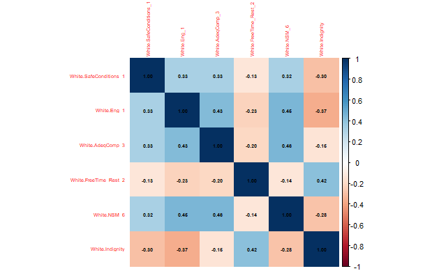

```r
#Correlation Coefficient Heat Map
JobSatVariablesWhite <- data.frame( White$SafeConditions_1 , White$Eng_1 , White$AdeqComp_3 , White$FreeTime_Rest_2 , White$NSM_6, White$Indignity)
correl<-corrplot(cor(as.matrix(JobSatVariablesWhite), use = "complete.obs", method = "pearson"),
                 method = "color",
                  tl.cex = 0.5,
                 number.cex = 0.5,
                 addCoef.col = "black")
```

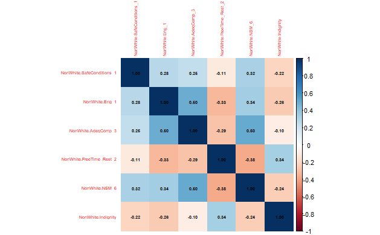

```r
#Correlation Coefficient Heat Map
JobSatVariablesNonWhite <- data.frame( NonWhite$SafeConditions_1 , NonWhite$Eng_1 , NonWhite$AdeqComp_3 , NonWhite$FreeTime_Rest_2 , NonWhite$NSM_6, NonWhite$Indignity)
correl<-corrplot(cor(as.matrix(JobSatVariablesNonWhite), use = "complete.obs", method = "pearson"),
                 method = "color",
                  tl.cex = 0.5,
                 number.cex = 0.5,
                 addCoef.col = "black")
```

**STEP 3** **First Group JobSat Regression Model**

```r
WhiteLinearProbModel <- lm(JobSat ~ YearsOld + Utah  + Married + Gender + Educ + log(OrgSize +1) + Income_1 + SAL + WorkExp + SafeConditions_1 + Eng_1 + AdeqComp_3 + FreeTime_Rest_2 + NSM_6 +Indignity  , data = White)
summary(WhiteLinearProbModel)
```

```
Call:
lm(formula = JobSat ~ YearsOld + Utah + Married + Gender + Educ +
    log(OrgSize + 1) + Income_1 + SAL + WorkExp + SafeConditions_1 +
    Eng_1 + AdeqComp_3 + FreeTime_Rest_2 + NSM_6 + Indignity,
    data = White)

Residuals:
       Min         1Q     Median         3Q        Max
-5.9359364 -0.6281722  0.1453956  0.8577432  3.4172546

Coefficients:
                      Estimate    Std. Error  t value              Pr(>|t|)
(Intercept)      -2.9186313952  1.0531515789 -2.77133             0.0058727 **
YearsOld         -0.0010653710  0.0090019883 -0.11835             0.9058576
Utah              0.0691925284  0.1636594141  0.42278             0.6727055
Married           0.2913218855  0.1700945101  1.71271             0.0876277 .
Gender           -0.0336578476  0.1612830722 -0.20869             0.8348098
Educ             -0.0046614332  0.0745277862 -0.06255             0.9501625
log(OrgSize + 1) -0.0896117166  0.1088862790 -0.82298             0.4110616
Income_1          0.0006086496  0.0010272319  0.59251             0.5538782
SAL               0.0908952667  0.1991253108  0.45647             0.6483254
WorkExp           0.0075319240  0.0088658143  0.84955             0.3961417
SafeConditions_1  0.1029527623  0.0634792841  1.62183             0.1057147
Eng_1             0.4148040963  0.0512163879  8.09905 0.0000000000000086765 ***
AdeqComp_3        0.3383291114  0.0547678327  6.17752 0.0000000017610993073 ***
FreeTime_Rest_2  -0.0598086166  0.0473457932 -1.26323             0.2073241
NSM_6             0.4330822464  0.0639126449  6.77616 0.0000000000505418125 ***
Indignity        -0.1661307704  0.0538519414 -3.08495             0.0021933 **
---
Signif. codes:  0 ‘***’ 0.001 ‘**’ 0.01 ‘*’ 0.05 ‘.’ 0.1 ‘ ’ 1

Residual standard error: 1.474661 on 360 degrees of freedom
  (7 observations deleted due to missingness)
Multiple R-squared:  0.6289715, Adjusted R-squared:  0.6135119
F-statistic: 40.68505 on 15 and 360 DF,  p-value: < 0.00000000000000022204
```

```r
#Regression Output Table
tidy(summary(WhiteLinearProbModel))
```

| term | estimate | std.error | statistic | p.value |
| --- | --- | --- | --- | --- |
| (Intercept) | -2.9186313952356 | 1.053151578947 | -2.77133078807 | 0.005872660944730504796463 |
| YearsOld | -0.0010653709611 | 0.009001988311 | -0.11834840530 | 0.905857611438239396228767 |
| Utah | 0.0691925283615 | 0.163659414070 | 0.42278367398 | 0.672705521796112426713421 |
| Married | 0.2913218855301 | 0.170094510061 | 1.71270598578 | 0.087627682964856026814893 |
| Gender | -0.0336578476261 | 0.161283072151 | -0.20868803637 | 0.834809805550718486699679 |
| Educ | -0.0046614332476 | 0.074527786221 | -0.06254624596 | 0.950162546547660857854112 |
| log(OrgSize + 1) | -0.0896117166053 | 0.108886279008 | -0.82298446987 | 0.411061636479979952696340 |
| Income_1 | 0.0006086496138 | 0.001027231904 | 0.59251432086 | 0.553878210899184542093110 |
| SAL | 0.0908952666723 | 0.199125310833 | 0.45647269196 | 0.648325377373916489354144 |
| WorkExp | 0.0075319240497 | 0.008865814285 | 0.84954678811 | 0.396141707639754314662639 |

[output cut: 6 more lines]

```r
#Confidence Intervals Table
confint_tidy(WhiteLinearProbModel, conf.level = 0.95)
```

| conf.low | conf.high |
| --- | --- |
| -4.989733446327 | -0.847529344144 |
| -0.018768460266 | 0.016637718344 |
| -0.252656059190 | 0.391041115913 |
| -0.043181803881 | 0.625825574941 |
| -0.350833179473 | 0.283517484221 |
| -0.151225948738 | 0.141903082243 |
| -0.303744800862 | 0.124521367651 |
| -0.001411479440 | 0.002628778668 |
| -0.300699683128 | 0.482490216472 |
| -0.009903368758 | 0.024967216858 |

[output cut: 6 more lines]

**Second Group JobSat Regression Model**

```r
NonWhiteLinearProbModel <- lm(JobSat ~ YearsOld + Utah  + Married + Gender + Educ + log(OrgSize +1) + Income_1 + SAL + WorkExp + SafeConditions_1 + Eng_1 + AdeqComp_3 + FreeTime_Rest_2 + NSM_6 +Indignity  , data = NonWhite)
summary(NonWhiteLinearProbModel)
```

```
Call:
lm(formula = JobSat ~ YearsOld + Utah + Married + Gender + Educ +
    log(OrgSize + 1) + Income_1 + SAL + WorkExp + SafeConditions_1 +
    Eng_1 + AdeqComp_3 + FreeTime_Rest_2 + NSM_6 + Indignity,
    data = NonWhite)

Residuals:
       Min         1Q     Median         3Q        Max
-3.3714793 -0.6245085  0.0409851  0.7877643  3.3363591

Coefficients:
                      Estimate    Std. Error  t value               Pr(>|t|)
(Intercept)      -3.2347064191  1.3388254517 -2.41608              0.0167867 *
YearsOld          0.0135263376  0.0109478981  1.23552              0.2184043
Utah             -0.1553901785  0.3324945700 -0.46735              0.6408723
Married           0.3743270100  0.1950941015  1.91870              0.0567593 .
Gender           -0.3204019198  0.1985009089 -1.61411              0.1084264
Educ              0.1432057585  0.0903742556  1.58459              0.1149869
log(OrgSize + 1) -0.1037623825  0.1302039759 -0.79692              0.4266487
Income_1          0.0008507020  0.0009472792  0.89805              0.3704766
SAL              -0.2988686332  0.2580396469 -1.15823              0.2484551
WorkExp          -0.0060337511  0.0114521690 -0.52687              0.5989990
SafeConditions_1  0.0188948618  0.0707131522  0.26720              0.7896475
Eng_1             0.5539689389  0.0569329915  9.73019 < 0.000000000000000222 ***
AdeqComp_3        0.2372852211  0.0763517170  3.10779              0.0022223 **
FreeTime_Rest_2  -0.0285763913  0.0601456525 -0.47512              0.6353337
NSM_6             0.3920102908  0.0817158786  4.79724           0.0000035928 ***
Indignity         0.0795170851  0.0574735079  1.38354              0.1683787
---
Signif. codes:  0 ‘***’ 0.001 ‘**’ 0.01 ‘*’ 0.05 ‘.’ 0.1 ‘ ’ 1

Residual standard error: 1.227218 on 164 degrees of freedom
  (3 observations deleted due to missingness)
Multiple R-squared:  0.6828561, Adjusted R-squared:  0.653849
F-statistic: 23.54103 on 15 and 164 DF,  p-value: < 0.00000000000000022204
```

Load broom package

```r
#Regression Output Table
tidy(summary(NonWhiteLinearProbModel))
```

| term | estimate | std.error | statistic | p.value |
| --- | --- | --- | --- | --- |
| (Intercept) | -3.2347064191066 | 1.3388254517125 | -2.4160777755 | 0.016786740197274132441185301 |
| YearsOld | 0.0135263376005 | 0.0109478980793 | 1.2355191382 | 0.218404281402463651406975487 |
| Utah | -0.1553901784591 | 0.3324945699880 | -0.4673465148 | 0.640872339217225639451669394 |
| Married | 0.3743270100394 | 0.1950941015081 | 1.9186997820 | 0.056759250676369929489162303 |
| Gender | -0.3204019198440 | 0.1985009089378 | -1.6141080742 | 0.108426394086877417310965654 |
| Educ | 0.1432057584701 | 0.0903742555612 | 1.5845857604 | 0.114986880601631716314336984 |
| log(OrgSize + 1) | -0.1037623824904 | 0.1302039759353 | -0.7969217664 | 0.426648669589952622693829198 |
| Income_1 | 0.0008507020394 | 0.0009472792466 | 0.8980477959 | 0.370476600139949652223947396 |
| SAL | -0.2988686332472 | 0.2580396468534 | -1.1582275704 | 0.248455058537282169606186244 |
| WorkExp | -0.0060337511012 | 0.0114521689732 | -0.5268653576 | 0.598999005257581540462297198 |

[output cut: 6 more lines]

```r
#Confidence Intervals Table
confint_tidy(NonWhiteLinearProbModel, conf.level = 0.95)
```

| conf.low | conf.high |
| --- | --- |
| -5.878263564552 | -0.591149273661 |
| -0.008090665690 | 0.035143340891 |
| -0.811912203186 | 0.501131846267 |
| -0.010893038934 | 0.759547059013 |
| -0.712348827881 | 0.071544988193 |
| -0.035241333903 | 0.321652850843 |
| -0.360854634889 | 0.153329869908 |
| -0.001019733586 | 0.002721137665 |
| -0.808376837901 | 0.210639571407 |
| -0.028646454707 | 0.016578952505 |

[output cut: 6 more lines]

**STEP 4**

**Logistic Regression** Does not worry at all coded as 0, any level of worry coded as 1.

```r
White$DummyEmployability1 <- ifelse(White$Employability1 == "4", 0, 1)
NonWhite$DummyEmployability1 <- ifelse(NonWhite$Employability1 == "4", 0, 1)
```

**First Group Worry Logistic Model**

```r
WhiteWorry <- glm(DummyEmployability1 ~ YearsOld + Utah  + Married + Gender + Educ + log(OrgSize +1) + Income_1 + SAL + WorkExp + SafeConditions_1 + Eng_1 + AdeqComp_3 + FreeTime_Rest_2 + NSM_6 +Indignity, family = binomial, data = White)
summary(WhiteWorry)
```

```
Call:
glm(formula = DummyEmployability1 ~ YearsOld + Utah + Married +
    Gender + Educ + log(OrgSize + 1) + Income_1 + SAL + WorkExp +
    SafeConditions_1 + Eng_1 + AdeqComp_3 + FreeTime_Rest_2 +
    NSM_6 + Indignity, family = binomial, data = White)

Coefficients:
                      Estimate    Std. Error  z value Pr(>|z|)
(Intercept)       2.2081208779  1.6669356917  1.32466 0.185284
YearsOld         -0.0217598343  0.0135799683 -1.60235 0.109079
Utah              0.3696857612  0.2483709239  1.48844 0.136634
Married          -0.3646573782  0.2597636042 -1.40380 0.160377
Gender           -0.1562767575  0.2454418364 -0.63672 0.524310
Educ              0.0808459355  0.1129759148  0.71560 0.474236
log(OrgSize + 1)  0.1270293348  0.1647165897  0.77120 0.440589
Income_1          0.0007761363  0.0016760434  0.46308 0.643310
SAL              -0.2351689263  0.3119500502 -0.75387 0.450929
WorkExp           0.0195823859  0.0132786887  1.47472 0.140287
SafeConditions_1  0.0393222397  0.0987998336  0.39800 0.690631
Eng_1            -0.0978669149  0.0847668919 -1.15454 0.248278
AdeqComp_3       -0.0254128928  0.0825934757 -0.30769 0.758321
FreeTime_Rest_2   0.1627894579  0.0720034356  2.26086 0.023768 *
NSM_6            -0.0978090338  0.1006940677 -0.97135 0.331375
Indignity         0.2026735881  0.0882419771  2.29679 0.021631 *
---
Signif. codes:  0 ‘***’ 0.001 ‘**’ 0.01 ‘*’ 0.05 ‘.’ 0.1 ‘ ’ 1

(Dispersion parameter for binomial family taken to be 1)

    Null deviance: 483.58160  on 375  degrees of freedom
Residual deviance: 439.39549  on 360  degrees of freedom
  (7 observations deleted due to missingness)
AIC: 471.39549

Number of Fisher Scoring iterations: 4
```

```r
#Logistic Regression Output in a Table
tidy(WhiteWorry, conf.int = FALSE, conf.level = 0.95, exponentiate = FALSE)
```

| term | estimate | std.error | statistic | p.value |
| --- | --- | --- | --- | --- |
| (Intercept) | 2.2081208778643 | 1.666935691707 | 1.3246587069 | 0.18528437483 |
| YearsOld | -0.0217598342915 | 0.013579968319 | -1.6023479422 | 0.10907868961 |
| Utah | 0.3696857611977 | 0.248370923863 | 1.4884421874 | 0.13663431787 |
| Married | -0.3646573781841 | 0.259763604233 | -1.4038047372 | 0.16037700294 |
| Gender | -0.1562767575057 | 0.245441836353 | -0.6367160539 | 0.52430981459 |
| Educ | 0.0808459355215 | 0.112975914761 | 0.7156032832 | 0.47423634578 |
| log(OrgSize + 1) | 0.1270293348036 | 0.164716589720 | 0.7711993978 | 0.44058875108 |
| Income_1 | 0.0007761363039 | 0.001676043403 | 0.4630764947 | 0.64330953765 |
| SAL | -0.2351689262788 | 0.311950050156 | -0.7538672495 | 0.45092893791 |
| WorkExp | 0.0195823859370 | 0.013278688675 | 1.4747228748 | 0.14028706359 |

[output cut: 6 more lines]

```r
#PseudoR2
PseudoR2(WhiteWorry, which = "all")
```

```
        McFadden      McFaddenAdj         CoxSnell       Nagelkerke    AldrichNelson  VeallZimmermann            Efron  McKelveyZavoina             Tjur              AIC
   0.09137259527    0.02519968839    0.11087392617    0.15321285081    0.10515841665    0.18692241447    0.11953087076    0.16858457078    0.11529239117  471.39549165020
             BIC           logLik          logLik0               G2
 534.26891794444 -219.69774582510 -241.79079860483   44.18610555947
```

```r
#% Change in Odds Table
tidy((exp(coef(WhiteWorry))-1) * 100)
```

| names | x |
| --- | --- |
| (Intercept) | 809.86029327600 |
| YearsOld | -2.15247969751 |
| Utah | 44.72797517435 |
| Married | -30.55654614545 |
| Gender | -14.46775592938 |
| Educ | 8.42038463987 |
| log(OrgSize + 1) | 13.54503255052 |
| Income_1 | 0.07764375756 |
| SAL | -20.95626872837 |
| WorkExp | 1.97753785500 |

[output cut: 6 more lines]

**Second Group Worry Logistic Model**

```r
NonWhiteWorry <- glm(DummyEmployability1 ~ YearsOld + Utah  + Married + Gender + Educ + log(OrgSize +1) + Income_1 + SAL + WorkExp + SafeConditions_1 + Eng_1 + AdeqComp_3 + FreeTime_Rest_2 + NSM_6 +Indignity, family = binomial, data = NonWhite)
summary(NonWhiteWorry)
```

```
Call:
glm(formula = DummyEmployability1 ~ YearsOld + Utah + Married +
    Gender + Educ + log(OrgSize + 1) + Income_1 + SAL + WorkExp +
    SafeConditions_1 + Eng_1 + AdeqComp_3 + FreeTime_Rest_2 +
    NSM_6 + Indignity, family = binomial, data = NonWhite)

Coefficients:
                      Estimate    Std. Error  z value  Pr(>|z|)
(Intercept)       4.7260287131  2.6940747889  1.75423 0.0793910 .
YearsOld          0.0200420847  0.0205098501  0.97719 0.3284735
Utah             -0.6102711990  0.6406683499 -0.95255 0.3408161
Married           0.9889826634  0.3882086680  2.54755 0.0108481 *
Gender           -0.0238976225  0.3804448743 -0.06281 0.9499139
Educ             -0.2099760980  0.1775298539 -1.18277 0.2369023
log(OrgSize + 1)  0.1484413857  0.2455053124  0.60464 0.5454208
Income_1         -0.0008932385  0.0018080253 -0.49404 0.6212773
SAL              -0.5261233920  0.5151772427 -1.02125 0.3071373
WorkExp          -0.0372229730  0.0218277412 -1.70531 0.0881374 .
SafeConditions_1 -0.2520417006  0.1398166245 -1.80266 0.0714418 .
Eng_1             0.0472279360  0.1106029516  0.42700 0.6693762
AdeqComp_3       -0.2540989583  0.1475134612 -1.72255 0.0849704 .
FreeTime_Rest_2  -0.0272470592  0.1170542228 -0.23277 0.8159377
NSM_6            -0.1745480991  0.1628900013 -1.07157 0.2839130
Indignity         0.4106219730  0.1268541352  3.23696 0.0012081 **
---
Signif. codes:  0 ‘***’ 0.001 ‘**’ 0.01 ‘*’ 0.05 ‘.’ 0.1 ‘ ’ 1

(Dispersion parameter for binomial family taken to be 1)

    Null deviance: 243.07202  on 179  degrees of freedom
Residual deviance: 193.84254  on 164  degrees of freedom
  (3 observations deleted due to missingness)
AIC: 225.84254

Number of Fisher Scoring iterations: 4
```

```r
#Logistic Regression Output in a Table
tidy(NonWhiteWorry, conf.int = FALSE, conf.level = 0.95, exponentiate = FALSE)
```

| term | estimate | std.error | statistic | p.value |
| --- | --- | --- | --- | --- |
| (Intercept) | 4.7260287131331 | 2.69407478888 | 1.7542307039 | 0.079390984130 |
| YearsOld | 0.0200420846553 | 0.02050985011 | 0.9771931315 | 0.328473547771 |
| Utah | -0.6102711989666 | 0.64066834992 | -0.9525539993 | 0.340816093771 |
| Married | 0.9889826634124 | 0.38820866797 | 2.5475543052 | 0.010848096741 |
| Gender | -0.0238976224853 | 0.38044487432 | -0.0628149414 | 0.949913867851 |
| Educ | -0.2099760980447 | 0.17752985390 | -1.1827650022 | 0.236902294447 |
| log(OrgSize + 1) | 0.1484413856821 | 0.24550531244 | 0.6046361450 | 0.545420784794 |
| Income_1 | -0.0008932385186 | 0.00180802525 | -0.4940409535 | 0.621277257024 |
| SAL | -0.5261233919625 | 0.51517724269 | -1.0212473463 | 0.307137265745 |
| WorkExp | -0.0372229729748 | 0.02182774121 | -1.7053057678 | 0.088137412442 |

[output cut: 6 more lines]

```r
#PseudoR2
PseudoR2(NonWhiteWorry, which = "all")
```

```
       McFadden     McFaddenAdj        CoxSnell      Nagelkerke   AldrichNelson VeallZimmermann           Efron McKelveyZavoina            Tjur             AIC             BIC
   0.2025304106    0.0708821841    0.2392854469    0.3229818535    0.2147606689    0.3737955131    0.2612560331    0.3383271621    0.2552577297  225.8425418557  276.9298514700
         logLik         logLik0              G2
 -96.9212709279 -121.5360086690   49.2294754822
```

```r
#% Change in Odds Table
tidy((exp(coef(NonWhiteWorry))-1) * 100)
```

| names | x |
| --- | --- |
| (Intercept) | 11184.65253872759 |
| YearsOld | 2.02442757519 |
| Utah | -45.67964671401 |
| Married | 168.84979732612 |
| Gender | -2.36143354210 |
| Educ | -18.93963792499 |
| log(OrgSize + 1) | 16.00248017192 |
| Income_1 | -0.08928396998 |
| SAL | -40.91088110404 |
| WorkExp | -3.65387144319 |

[output cut: 6 more lines]

[output not shown]